# MATH 141

## Statistical errors

[figure not shown]

## Jury trial analogy

[figure not shown]

## Confidence Intervals

**Confidence Interval**: a plausible range of values for a population parameter.

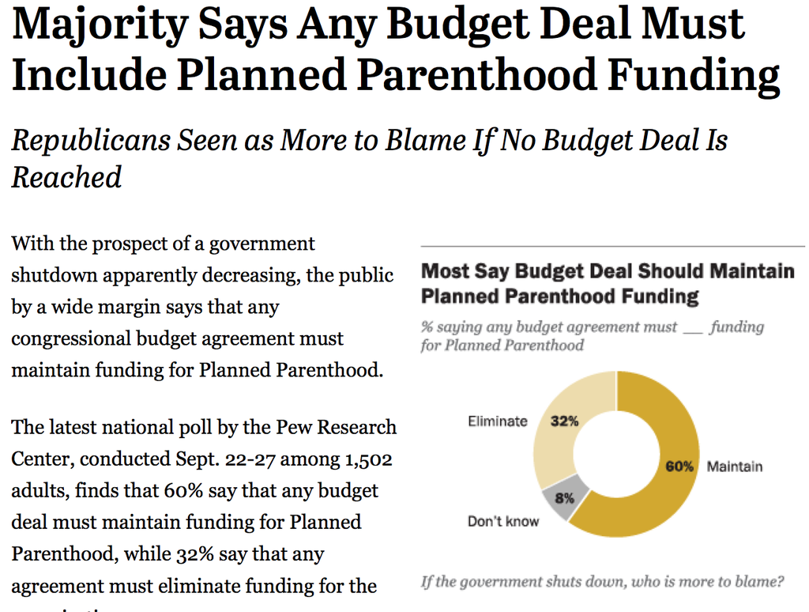

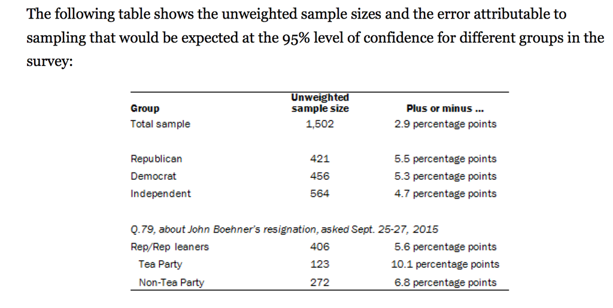

## Construction of a CI

If the distribution of the point estimate can be well-approximated by the Normal Distribution:

\[ \textrm{point estimate} \pm \textrm{margin of error} \] \[ \textrm{point estimate} \pm 1.96 \times SE \]

- *point estimate*: \(\hat{p}\), \(\bar{x}\), \(\hat{p}_1 - \hat{p}_2\)
- *standard error (SE)*: standard deviation of the sampling distribution of the point estimate.

## Question

"The proportion of Americans who want to support funding for Planned Parenthood is estimated to be between 57.1% and 62.9% with 95% confidence." Which of the TWO following interpretations are reasonable?

1. The interval [.571, .629] provides a plausible range for \(\hat{p}\)
2. We are certain that the population proportion lies within this interval.
3. If we took many more samples of the same size and computed many \(\hat{p}\)'s  
   and many CIs, around 95% of those CIs would contain the population  
   proportion \(p\).
4. 95% of all surveys conducted with differing sample sizes will have between 57.1% and 62.9% in support of funding Planned Parenthood.
5. We are 95% confident that the true proportion of Americans who want to support funding for Planned Parenthod is between 57.1% and 62.9%.

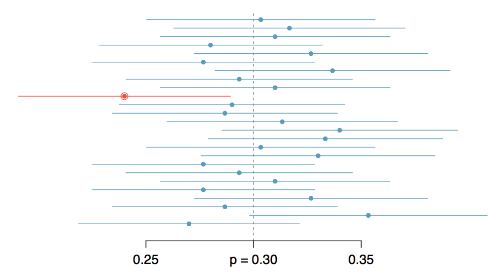